# Homework 4 Solutions

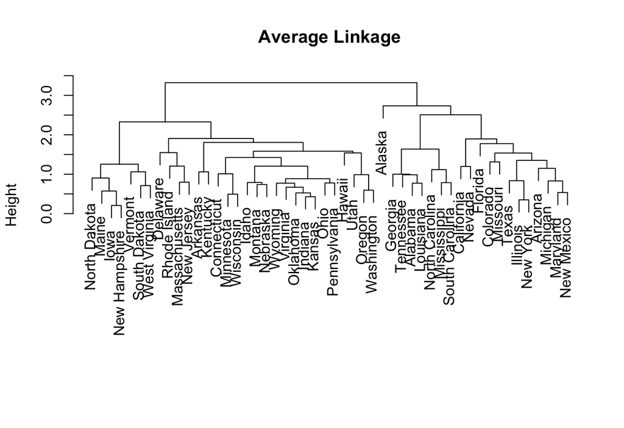

```r
#dendrogram
plot(hc_average, main = "Average Linkage", xlab = "", sub = "")
```

The dendogram shows some interesting results. Overall, the states that are grouped early on have a geographic relationships, e.g., Georgia, Tennessee, Alabama, and Louisiana, or Oregon and Washington, however, this is not always the case, e.g., Iowa and New Hampshire, or Illinois and New York.

If we were to split into two clusters, the right most group contains large states and those that are in the south eastern part of the country.

4. Compare the clustering results across methods. Which sites consistently cluster together?

One way to compare clustering relationships is to use the RAND index. To understand RAND let ${\delta}_1$ and ${\delta}_2$ be two groups of a dataset. For example, one is an estimated grouping and the other it the true grouping. In all there are $\binom{n}{2}$ pairs of observations. Let $a=$number of pairs in the same subset in ${\delta}_1$ and in the same subset in ${\delta}_2$, and $a=$number of pairs in the a different subset in ${\delta}_1$ and a different subset in ${\delta}_2$. Then
$$Rand =
\frac{a+b}{\binom{n}{2}}.$$
The adjusted Rand index is the corrected-for-chance version of the Rand index.

Let’s compare all the results:

```r
RRand(km_res$cluster, pam_res$clustering)
```

```
##    Rand adjRand  Eindex
##  0.7265  0.4586  0.2466
```

```r
RRand(km_res$cluster, cutree(hc_average, k = 2))
```

```
##    Rand adjRand  Eindex
##  0.7265  0.4586  0.2466
```

```r
RRand(km_res$cluster, gmm_res$classification)
```

```
##    Rand adjRand  Eindex
##  0.8408  0.6236  0.1673
```

```r
RRand(cutree(hc_average, k = 2), pam_res$clustering)
```

```
##    Rand adjRand  Eindex
##  1.0000  1.0000  0.5083
```

```r
RRand(cutree(hc_average, k = 2), gmm_res$classification)
```

```
##    Rand adjRand  Eindex
##  0.8367  0.6755  0.3452
```

Interestingly, PAM and heirical clustering have identical results. After that, K-means and the Gaussian mixture model are the most alike.

5. How could the clustering results inform violent crime policy?

Below are the average values of the the predictor variables by K-means cluster:

| Cluster | Murder | Assault | UrbanPop | Rape |
| --- | --- | --- | --- | --- |
| 1 | 10.815 | 257.385 | 76.000 | 33.192 |
| 2 | 5.656 | 138.875 | 73.875 | 18.781 |
| 3 | 13.938 | 243.625 | 53.750 | 21.413 |
| 4 | 3.600 | 78.538 | 52.077 | 12.177 |

In the K-means results, Cluster 3 exhibits the highest mean rate of murder, while Cluster 1 shows the highest rates of assault and rape. Clusters 2 and 4 generally have lower levels of violent crime. Clusters 1 and 2 also correspond to states with more urban populations, whereas Clusters 3 and 4 tend to represent less urban areas.

Below are some countries in each cluster:

| Cluster1 | Cluster2 | Cluster3 | Cluster4 |
| --- | --- | --- | --- |
| Alaska | Connecticut | Alabama | Idaho |
| Arizona | Delaware | Arkansas | Iowa |
| California | Hawaii | Georgia | Kentucky |
| Colorado | Indiana | Louisiana | Maine |
| Florida | Kansas | Mississippi | Minnesota |
| Illinois | Massachusetts | North Carolina | Montana |

These match the above trends, but not exclusively (e.g., Alaska does not have many urban populations). Recognizing these trends across clusters can help policymakers tailor interventions, allocate resources more effectively, and encourage collaboration among states facing similar public safety challenges.